# Bayesian Statistics

## Correlation in JASP

- **1** Load *Presidents.csv* into JASP. Run descriptive statistics and summarize what you find.
- **2** Conduct a classical correlation test.
  - **2a** Interpret the resulting *p*-value and confidence interval.
  - **2b** Are these concepts valid for the current data set? *Hint:* think about the data generating process.
- **3** Conduct a Bayesian correlation test.
  - **3a** Estimate the posterior distribution and interpret the Bayes factor.
  - **3b** Does the default prior in JASP make sense?
  - **3c** Run a robustness check. What do you conclude?
  - **3d** Run a sequential analysis. What do you conclude?

## t-test in JASP

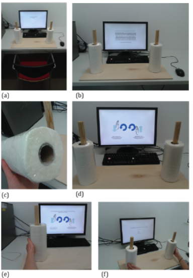

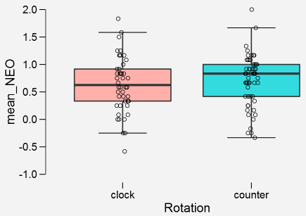

## t-test in JASP

- **1** Load *KitchenRolls.csv* into JASP. Run descriptive statistics and summarize the data graphically.
- **2** Conduct a classical t-test.
  - **2a** Interpret the resulting *p*-value and confidence interval.
  - **2b** Are these concepts valid for the current data set? *Hint:* think about the data generating process.
- **3** Conduct a Bayesian t-test.
  - **3a** Estimate the posterior distribution and interpret the Bayes factor.
  - **3b** Does the default prior in JASP make sense?
  - **3c** Run a robustness check. What do you conclude?
  - **3d** Run a sequential analysis. What do you conclude?
- **4** Conduct a Bayesian one-sided t-test. Is this approach justifiable?

## Wrap-up

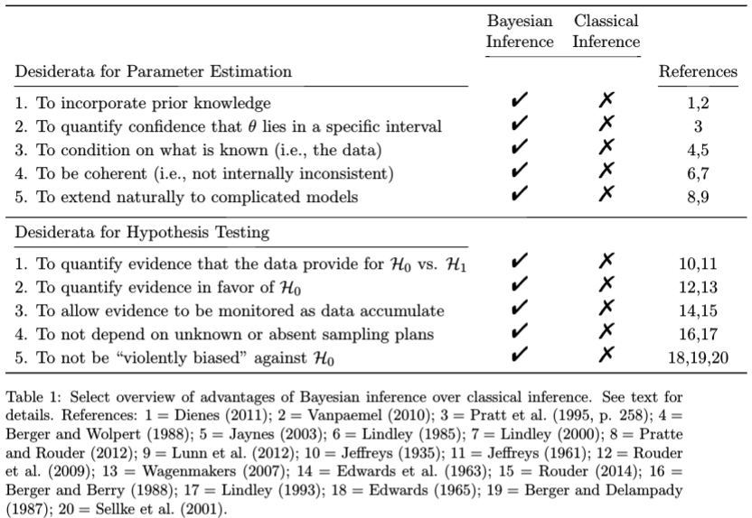

## Final thoughts

## Solidify your learning

- [Exercises](https://github.com/fdabl/Intro-Stats/blob/master/exercises/exercises.pdf) for this workshop
- [A First Lesson in Bayesian Inference](http://lmpp10e-mucesm.srv.mwn.de:3838/felix/BayesLessons/BayesianLesson1.Rmd) by Eric-Jan Wagenmakers
- [Improving your statistical inferences](https://www.coursera.org/learn/statistical-inferences/home/welcome) by Daniel Lakens

## Thanks to

- EJ Wagenmakers and his lab for writing the wittiest exposures to Bayesian statistics and providing user-friendly, open-source, free statistical software
- Richard Morey (and Jeffrey Rouder) for the BayesFactor R package, doing much of the heavy lifting in JASP (see [here](https://bayesfactor.blogspot.de/))
- Michael Franke for allowing me to help him create a course on Bayesian statistics and cognitive modeling (see [here](http://www.sfs.uni-tuebingen.de/~mfranke/bda+cm2015/))
- All the people on Twitter engaging in fruitful discussions, creating an atmosphere of learning unparalleled in University curricula
- All the people who blog about open science and methods